# MA415 Final Project: Analysis of Tweets on Uber Services

Wjdan Alharthi

December 14, 2017

[figure not shown]

# Introduction

Uber has dominated the private transportation business in the past 8 years. What began in 2008 as a luxury car service in San Francisco, CA is now valued at $70 billion and operates in more than 300 cities worldwide. To passengers, it’s a convenient, affordable service. However, recently Uber rides fares have increased very quickly in the past year. In addition, they have implmented new algorithms for finding fastest routes and optimizing the pick up and drop off schedule of shared rides, and such new features had positive and negative impact on the quality of service. Therefore, for this analysis, I was curious about what the tweets on Uber say, how frequent they are, and from where are they being tweeted! I will use Twitter’s API to obtain tweets on Uber and analyze them in R.

# Requirements

Load the needed libraries for this analysis. I wrote a function called GetPackage() to install the CRAN-supported packages automatically. Then I created a list of the packages we need and used a for-loop to call GetPackage() on the list of packages.

```r
# input: package name, it loads it and installs if in needed
GetPackage <- function(x) {
  x <- as.character(x)
  if (!require(x,character.only=TRUE)) {
   install.packages(pkgs=x,repos="http://cran.r-project.org")
   require(xcharacter.only=TRUE)
 }
}

# list of needed packages
LIST_OF_PACKAGES <- c("twitteR", "ROAuth", "devtools",
                      "ggplot2", "syuzhet", "Hmisc",
                      "stringr", "tm", "plyr", "dplyr",
                      "mapview", "leaflet", "maps", "tmap")

# load all packages in the list
for (psk_name in LIST_OF_PACKAGES){
  GetPackage(psk_name)
}
```

# Preparation for Data Collection and Cleaning

In this section, we will collect the tweets and clean them for the purposes of this analysis.

## Twitter Authentication Setup

After creating a developer account on Twitter, I obtained the necessary tokens to setup the twitter API authentication. Below are my keys and a call to setup_twitter_oauth() for validation.

```r
# twitter auth vars
CONSUMER_KEY="n0VQmi2OXrFQxoPvYvx2FIknI"
CONSUMER_SECRET="hTkHfzJrIzQvpwAJLZAQYoyz3iryEEbX8gBlJloQedr51pNlRw"
TOKEN="871919779426308099-Yn40D6rcq7zcC2qJowKB8aUvgSLpZVt"
TOKEN_SECRET="aOBkoIl6wJXYcHMgstf9BuK3OapE5DNKMyr0sfycr3tQE"

# twitter auth set-up
setup_twitter_oauth(consumer_key=CONSUMER_KEY,
                      consumer_secret=CONSUMER_SECRET,
                      access_token=TOKEN,
                      access_secret=TOKEN_SECRET)
```

```
## [1] "Using direct authentication"
```

## Function for Search Related Tweets

Next we create the search name. Since twitter API allows us to search for terms with logical operators such as “OR” and “AND”, I constructed my search term such that it fetches tweets with “@” sign for replies and mentions, or “#” sign for related hashtags, and a general use of the word.

After that, I use searchTwitter() functionto search for tweets with the contructed search terms above. I also specify the language as english, and the number of tweets as n. This function will be useful for tweets collection later.

```r
brand <- "uber"

Search_Twitter <- function(key_word, n=500) {
  # contructing the search clause
  search_term <- paste0('@', key_word, ' OR ', key_word, ' OR ', '#', key_word)

  # print
  print(paste0("searching: ", search_term))

  # search twitter
  twtList <- searchTwitter(search_term, n=n, lang="en", retryOnRateLimit=120)
  twtList <- strip_retweets(twtList, strip_manual = TRUE, strip_mt = TRUE)

  # convert to a dataframe and return
  return (twListToDF(twtList))
}
```

## Extracting and Cleaning Tweets

searchTwitter() returns a special type of objects of type ‘status-class’ which contains information about the retreived tweets. We need to extract the texts from these objects, and clean the text from common charachters that we don’t want to include in our analysis. We will use the clean text for the sentimental analysis and frequency graphs.

```r
# takes a dataframe of tweet objects then extracts and cleans text
CleanTweets <- function(df) {
  # extract text
  clean_text = df$text

  #removes emoticons #ref: (Hicks , 2014)
  clean_text <- sapply(clean_text,function(row) iconv(row, "latin1", "ASCII", sub=""))
  clean_text = gsub("&amp", "", clean_text)       # & sign
  clean_text = gsub("(RT|via)((?:\\b\\W*@\\w+)+)", "", clean_text)  #retweets
  clean_text = gsub("@\\w+", "", clean_text)        # @'s
  clean_text = gsub("[[:punct:]]", "", clean_text)  # punctuation
  clean_text = gsub("[[:digit:]]", "", clean_text)  # digits
  clean_text = gsub("http\\w+", "", clean_text)     # urls
  clean_text = gsub("[ \t]{2,}", "", clean_text)    # brakets curly and sq
  clean_text = gsub("^\\s+|\\s+$", "", clean_text)  # spaces

  # remove common words
  # collected common words in english
  common_words <- c('the', 'and', 'that', 'not', 'you', 'this', 'but',
                    'his', 'they', 'her', 'she', 'will', 'one', 'all',
                    'would', 'there', 'the', 'for', 'with', 'from',
                    'about', 'into', 'over', 'after')
  for (word in common_words) {
    clean_text = gsub(word, "", clean_text)
  }

  # also the search term!
  clean_text = gsub(tolower(brand), "", clean_text)
  clean_text = gsub(capitalize(brand), "", clean_text)

  return (clean_text)
}
```

# Data Collection

Now that we have the functions to collection and clean the tweets, let’s collect tweets on Uber!

Other cleaning operations on the dataframe include removing uneeded columns, omitting NA rows. However, for the latter, since most of the tweets are not geocoded, most rows will be omitted. Thus, if we need to remove NA’s, we must specify the columns we want to clean (not needed for this analysis).

```r
brand <- "Uber"

########################################## searches

#tweets <- Search_Twitter(brand, n=2000)

########################################## reads

tweets <- read.csv("./data/tweetsDB.csv", header=TRUE)

########################################## cleaning

# remove duplicate tweets!
# tweets = tweets[!duplicated(tweets$text),]

# get text
cleaned_tweets <- CleanTweets(tweets)

# PROBLEM HERE: 99% of the tweets are not geocoded ==> all will be omitted!
#tweets = na.omit(tweets) # removing the rows with missing values.
```

## Sentimental Analysis

I use get_nrc_sentiment() from the `syuzhet` package which implements Saif Mohammad’s NRC Emotion lexicon. It uses a list of words and their associations with eight emotions (anger, fear, anticipation, trust, surprise, sadness, joy, and disgust) and two sentiments (negative and positive)” (See http://www.purl.org/net/NRCemotionlexicon). Below is a function that uses the package to analyse the tweets, and returns a dataframe with names columns.

```r
GetSentimentalTable <- function(twts_txt) {
    # analyze with the library
    ext_sentiment <- get_nrc_sentiment(twts_txt,  language = "english")

    # aggregate sentiments into a new object
    sentimentTotals <- data.frame(colSums(ext_sentiment))

    # give column names
    names(sentimentTotals) <- "count"
    sentimentTotals <-
      cbind("sentiment" = rownames(sentimentTotals), sentimentTotals)
  rownames(sentimentTotals) <- NULL

    return (sentimentTotals)
}
```

Now we can analyze the tweets using the function above, and plot it with ggplot2!

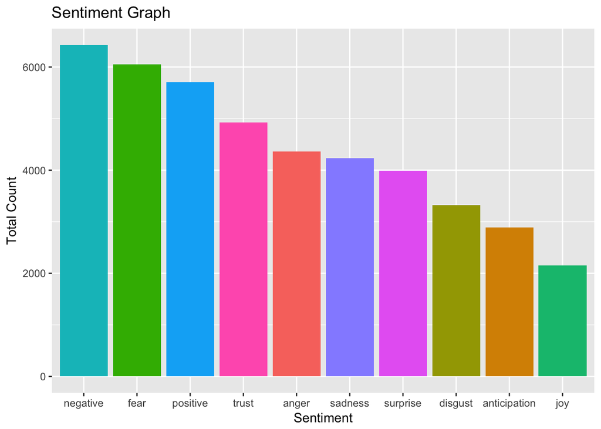

```r
#df.sentiment <- GetSentimentalTable(cleaned_tweets)
#write.csv(df.sentiment, file="./data/general_sentiment.csv", row.names=FALSE)
df.sentiment <- read.csv("./data/general_sentiment.csv", header=TRUE)

ggplot(df.sentiment, aes(x = reorder(sentiment, -count), y = count)) +
        geom_bar(aes(fill = sentiment), stat = "identity") +
        theme(legend.position = "none") +
        xlab("Sentiment") + ylab("Total Count") + ggtitle("Sentiment Graph")
```

```r
ggsave("./assets/EDA_sentiment.png")
```

```r
# get total number of words
total_word_count <- sum(df.sentiment$count)

negative_feelings <- list('anger', 'disgust', 'fear', 'sadness', 'negative')
positive_feelings <- list('joy', 'trust', 'positive', "anticipation")
neutral_feelings <- list('surprise')

negative_total =
  sum(df.sentiment[df.sentiment$sentiment %in% negative_feelings,]$count)
positive_total =
  sum(df.sentiment[df.sentiment$sentiment %in% positive_feelings,]$count)
neutral_total =
  sum(df.sentiment[df.sentiment$sentiment %in% neutral_feelings,]$count)

negative_precentage = (negative_total/total_word_count)*100
positive_precentage = (positive_total/total_word_count)*100
neutral_precentage = (neutral_total/total_word_count)*100

polatiryTable <- data.frame("polarity" = character(), "precentage" = double(), stringsAsFactors=FALSE)
polatiryTable <- rbind(polatiryTable, data.frame("polarity" = "positive", "precentage"=round(positive_precentage, digit=2)))
polatiryTable <- rbind(polatiryTable, data.frame("polarity" = "negative", "precentage"=round(negative_precentage, digit=2)))
polatiryTable <- rbind(polatiryTable, data.frame("polarity" = "neutral", "precentage"=round(neutral_precentage, digit=2)))

polatiryTable
```

```
##   polarity precentage
## 1 positive      35.56
## 2 negative      55.38
## 3  neutral       9.06
```

```r
write.csv(polatiryTable, file="./data/polarity.csv", row.names=FALSE)
```

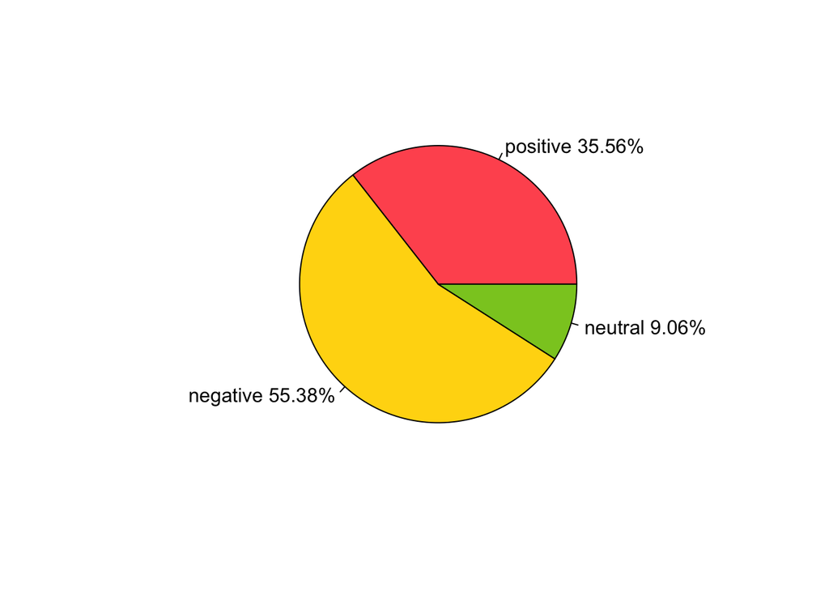

```r
# used online color palette generator for codes
colors=c("#FF595E", "#FFD70F", "#8AC926")

pie(as.numeric(polatiryTable$precentage),
    labels = paste0(polatiryTable$polarity, " ",
                    polatiryTable[polatiryTable$polarity ,]$precentage, "%")
    , col=colors)
```

Before we leave sentiments alone, I wanted to explore the sentiments of the tweets overtime. Below is a function that takes a list of tweets and returns a list of their sentiment scores.

```r
GetSentimentPerTweet <- function(tweets){
  # prepare vars
  negative_feelings <- list('anger', 'disgust', 'fear', 'sadness', 'negative')
  positive_feelings <- list('joy', 'trust', 'positive', 'anticipation')
  new_col <- NULL

  # for each tweet, analyze sentiment
  for (t in tweets) {
    sent <- GetSentimentalTable(t)

    # get positiveness and negativeness
    negative_total = sum(sent[sent$sentiment %in% negative_feelings,]$count)
    positive_total = sum(sent[sent$sentiment %in% positive_feelings,]$count)

    # calculate score only if both are non-negative
      score <- positive_total - negative_total

      # add new results to col
      new_col <- rbind(new_col, score)
  }

  return(new_col)
}
```

Now we can use the function above to get the scores of tweets and plot using ggplot. But first, we need to prepare the data with the scores, and remove uneeded entries.

```r
# copy of tweets
temp <- tweets

# replace text with cleaned text
temp$text <- cleaned_tweets

# remove uneeded columns
temp <- subset(temp, select = c("text", "created", "retweetCount"))

# convert the date formante to a simple one
temp$created <- as.Date(temp$created)

# obtain the sentiment scores per tweet
#score <- GetSentimentPerTweet(temp$text)
#write.csv(score, file="./data/detailed_sentiment.csv", row.names=FALSE)
score <- read.csv("./data/detailed_sentiment.csv", header=TRUE)

# add the new scores col to out dataframe and create a new dataframe
df.scores <- cbind(temp, score)
names(df.scores) <- c("text", "created", "retweetCount", "score")

# now I want to add a col called sentiment, and I want it to have a string representation
# of the score such that: if score < 0 --> neg, score > 0 --> pos, otherwise neutral
lst <- list(df.scores$score)

# use double ifelse to get the string sentiment
sentiment <- rapply(lst ,
  function(x) ifelse(x < 0, 'negative', ifelse(x > 0, 'positive', 'neutral')))

df.scores <- cbind(df.scores, sentiment)
names(df.scores) <- c("text", "created", "retweetCount", "score", "sentiment")
```

Let’s plot the sentiment of tweets over time!

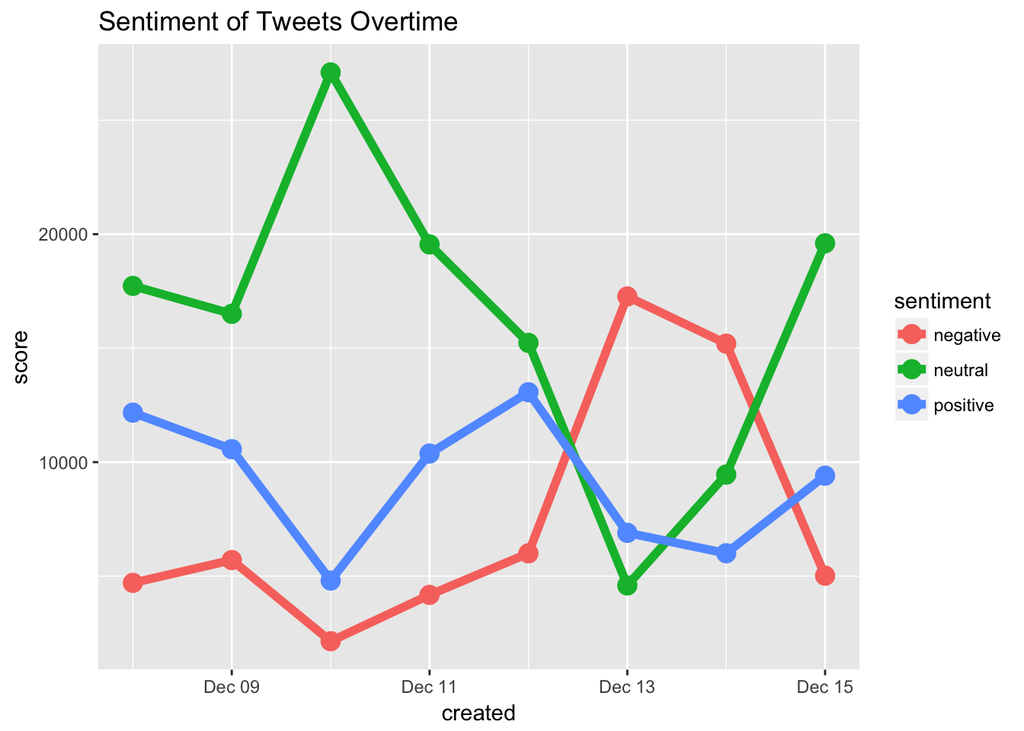

```r
# we don't need text and retweetCount cols anymore, get rid of it!
df.time <- subset(df.scores, select = c("created", "score", "sentiment"))

# before we group by and summarize
# since I want to plot a line obove the x axis
# I will neutralize the negatives by adding the min score
# to all the scores
scalar <- min(df.time$score)
df.time$score <- df.time$score + -1*scalar

# NOW the fun begins, order, group_by and summarize!
df.ordered <- df.time[order(sentiment),]

df.ordered <- df.ordered %>% group_by(sentiment, created) %>%
  summarise(score=sum(score))
df.ordered = na.omit(df.ordered)

# ggplot that
ggplot(df.ordered, aes(created, score)) +
  geom_line(aes(group=sentiment, color=sentiment), size=2) +
  geom_point(aes(group=sentiment, color=sentiment), size=4) +
  ggtitle("Sentiment of Tweets Overtime")
```

```r
ggsave("./assets/EDA_sentimentTime.png")
```

We notice a spike in the negative line on Dec 13, 2017. I was curious and I googled “uber december 13” and it turned out that one of the popular national news is [“Uber Under Criminal Investigation, Justice Dept. Confirms in Letter to Court”](https://www.nytimes.com/2017/12/13/technology/uber-waymo-driverless-cars.html).

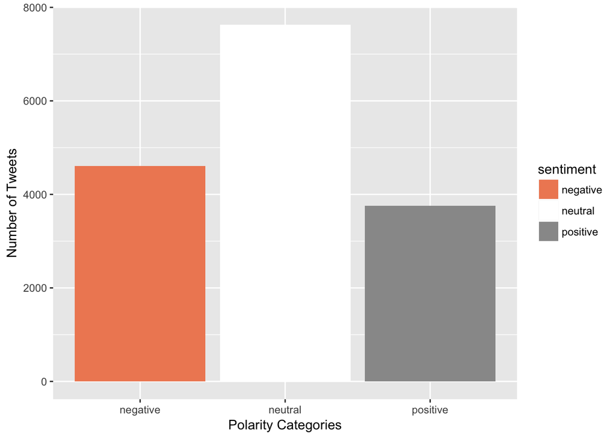

```r
# keep the cols we need
df.retweet <- subset(df.scores, select = c("retweetCount", "score", "sentiment"))

df.retweet <- df.retweet[order(sentiment),]

ggplot(df.retweet, aes(x=sentiment)) +
  geom_bar(aes(y=..count.., fill=sentiment)) +
  scale_fill_brewer(palette="RdGy") +
  theme(legend.position="right") +
  ylab("Number of Tweets") + xlab("Polarity Categories")
```

```r
ggsave("./assets/EDA_sentimentRetweet.png")
```

## Statistical Analysis

I wrote a function GetFrequencyTable() that returns a dataframe of the tweets words and their frequencies using a TermDocumentMatrix() and basic sum(). Then convered to a dataframe. I will use it to create a dataframe of words and their frequencies in descending order and omitting frequencie equal to 1. Then I can and use statistical functions on them.

Using statistical equations and simple math functions on the frequenies table

```r
#frequencyTable <- GetFrequencyTable(cleaned_tweets)
#write.csv(frequencyTable, file="./data/frequencies.csv", row.names=FALSE)
frequencyTable <- read.csv("./data/frequencies.csv", header=TRUE)

p1 <- paste("mean is: ", mean(frequencyTable$freq))
p2 <- paste("median is: ", median(frequencyTable$freq))
p3 <- paste("standard dev is: ", sd(frequencyTable$freq))
p4 <- paste("min is: ", min(frequencyTable$freq))
p5 <- paste("max is: ", max(frequencyTable$freq))
p6 <- paste("qualtile is: ")

p1
```

```
## [1] "mean is:  27.100307062436"
```

```r
p2
```

```
## [1] "median is:  4"
```

```r
p3
```

```
## [1] "standard dev is:  156.581448355778"
```

```r
p4
```

```
## [1] "min is:  2"
```

```r
p5
```

```
## [1] "max is:  3005"
```

```r
print(quantile(frequencyTable$freq, c(0.05,0.1,0.25,0.5,0.75,0.9,0.95)))
```

```
##  5% 10% 25% 50% 75% 90% 95%
##   2   2   2   4  10  29  64
```

Finally the qualtiles. 95% of the words have frquencies less than 64, and 50% of the words have frequencies less than or equal to 4.

### Bar Graph

And a bargraph of the most frequent words

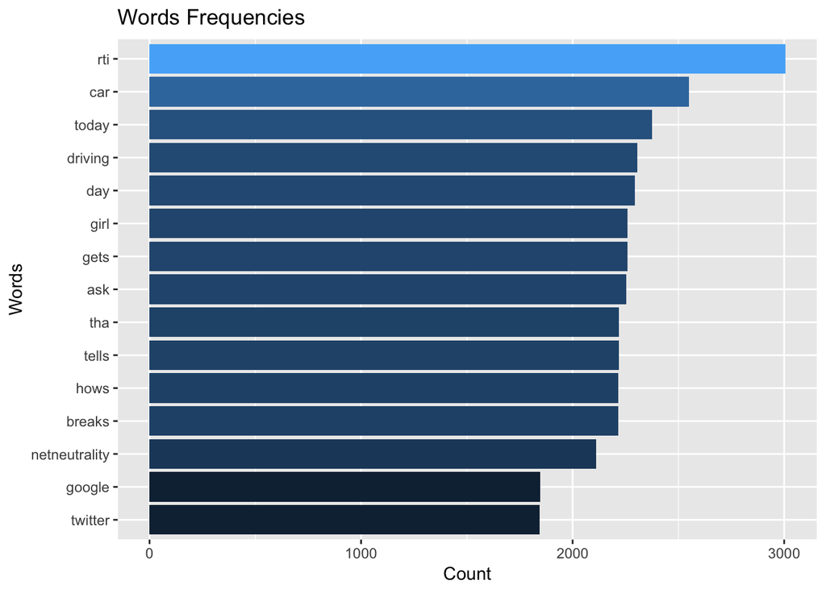

```r
# get the head - most frequent words
barGraph <- head(frequencyTable, n=15)

# ggplot bargraph!
ggplot(barGraph, aes(x = reorder(words, freq), y = freq)) +
        geom_bar(aes(fill = freq), stat = "identity") +
        theme(legend.position = "none") +
        xlab("Words") + ylab("Count") + ggtitle("Words Frequencies") + coord_flip()
```

```r
ggsave("./assets/EDA_frequency.png")
```

### Histogram

A histogram of frequecies of words.

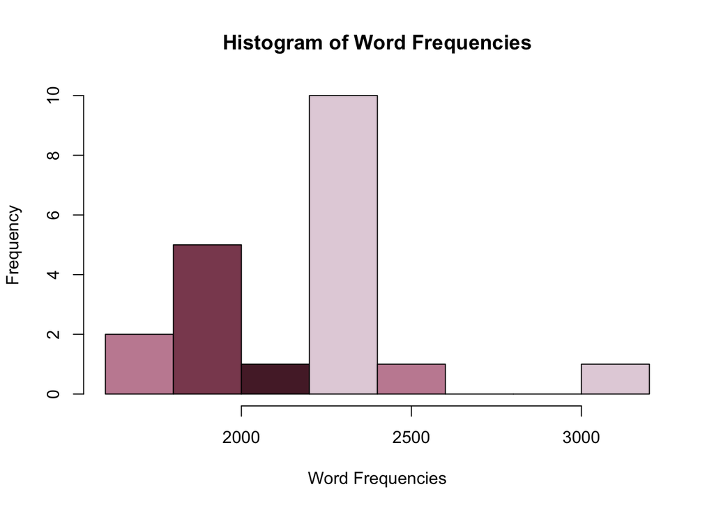

```r
# get mot frequent
histog <- head(frequencyTable, 20)

# plot!!
# used an online palette generator tool to obtain color codes
colors=c("#C58CA1", "#8B4A5E", "#562433", "#E3D2DC")
hist(histog$freq, right=FALSE, col=colors, main="Histogram of Word Frequencies", xlab="Word Frequencies")
```

### Equation

Before we finish, I create a simple function that calculates the probability of a set of words in the tweets we collected. I tested it with a sample of the tweets.

```r
CalculateProbability <- function(words){
  # the if statement make sure that the word is already used otherwise it returns the value 0
  for (w in words) {
    if (w %in% frequencyTable$word) {
      u = frequencyTable[which(frequencyTable$word == w),]
      num = as.numeric(u$freq)
      prob = round((num/sum(as.numeric(frequencyTable$freq)))*100, digit=2)
    } else {
      prob = 0
    }
    phrase <- paste(w, ": ", prob)
    print(phrase)
  }
}

test_set <- head(frequencyTable$words, n=15)
CalculateProbability(test_set)
```

```
## [1] "rti :  2.27"
## [1] "car :  1.93"
## [1] "today :  1.79"
## [1] "driving :  1.74"
## [1] "day :  1.73"
## [1] "girl :  1.71"
## [1] "gets :  1.71"
## [1] "ask :  1.7"
## [1] "tha :  1.68"
## [1] "tells :  1.68"
## [1] "hows :  1.67"
## [1] "breaks :  1.67"
## [1] "netneutrality :  1.6"
## [1] "google :  1.39"
## [1] "twitter :  1.39"
```

# Where are they tweeting from?

Another interesting data visualization tool is maps! We can extract the tweets on the brand and isolate the tweets with geocodes (longitude and latitude), and plot them on an interactive map! Most tweets returned by Twitter’s API are not geocoded. Out of the 16,000 tweets I collected, only 13 of them are geocoded. Plotted below!

```r
# removing NA geocodes
geo_tweets = tweets[!is.na(tweets$longitude),]
geo_tweets = tweets[!is.na(tweets$latitude),]

m <- leaflet(map) %>% addTiles()

# adding the locations of the tweets.
m <- m %>% addCircles(map, lng = as.numeric(geo_tweets$longitude), lat = as.numeric(geo_tweets$latitude),
                 popup = NULL, weight = 8, radius = 40, color = "#fb3004", stroke = TRUE, fillOpacity = 0.8)

m
```

[interactive chart not shown]